# Income

Daria Ivanushenko

5/10/2022

# Report for 1996

## **Data Description**

Dataset describes income depending on different demographical characteristics. Main goal of the analysis is to predict income taking into account their age, country of origin, eduaction and etc.

**Columns:**

- **age**: the age of an individual Integer greater than 0
- **workclass**: a general term to represent the employment status of an individual Private, Self-emp-not-inc, Self-emp-inc, Federal-gov, Local-gov, State-gov, Without-pay, Never-worked.
- **fnlwgt**: this is the number of people the census believes the entry represents. Integer greater than 0
- **education**: the highest level of education achieved by an individual. Bachelors, Some-college, 11th, HS-grad, Prof-school, Assoc-acdm, Assoc-voc, 9th, 7th-8th, 12th, Masters, 1st-4th, 10th, Doctorate, 5th-6th, Preschool.
- **education-num**: the highest level of education achieved in numerical form. Integer greater than 0
- **marital-status**: marital status of an individual. Married-civ-spouse corresponds to a civilian spouse while Married-AF-spouse is a spouse in the Armed Forces. Married-civ-spouse, Divorced, Never-married, Separated, Widowed, Married-spouse-absent, Married-AF-spouse.
- **occupation**: the general type of occupation of an individual Tech-support, Craft-repair, Other-service, Sales, Exec-managerial, Prof-specialty, Handlers-cleaners, Machine-op-inspct, Adm-clerical, Farming-fishing, Transport-moving, Priv-house-serv, Protective-serv, Armed-Forces.
- **relationship**: represents what this individual is relative to others. For example an individual could be a Husband. Each entry only has one relationship attribute and is somewhat redundant with marital status. We might not make use of this attribute at all Wife, Own-child, Husband, Not-in-family, Other-relative, Unmarried.
- **race**: Descriptions of an individual’s race White, Asian-Pac-Islander, Amer-Indian-Eskimo, Other, Black.
- **sex**: the biological sex of the individual Male, female
- **capital-gain**: capital gains for an individual Integer greater than or equal to 0
- **capital-loss**: capital loss for an individual Integer greater than or equal to 0
- **hours-per-week**: the hours an individual has reported to work per week continuous
- **native-country**: country of origin for an individual United-States, Cambodia, England, Puerto-Rico, Canada, Germany, Outlying-US(Guam-USVI-etc), India, Japan, Greece, South, China, Cuba, Iran, Honduras, Philippines, Italy, Poland, Jamaica, Vietnam, Mexico, Portugal, Ireland, France, Dominican-Republic, Laos, Ecuador, Taiwan, Haiti, Columbia, Hungary, Guatemala, Nicaragua, Scotland, Thailand, Yugoslavia, El-Salvador, Trinadad&Tobago, Peru, Hong, Holand-Netherlands.
- **income_bracket**: whether or not an individual makes more than $50,000 annually. <= 50K, >50K

```r
# options(repos = list(CRAN="http://cran.rstudio.com/"))
# install.packages("dplyr")
# install.packages("skimr")
# install.packages('readr', repos = "http://cran.us.r-project.org")
# install.packages("skimr")
# install.packages("tidyr")
# install.packages("rnaturalearth")
# install.packages("cowplot")
# install.packages("sf")
# install.packages("ggmap")
# install.packages("leaflet")
library(skimr)
library(readr)
library(dplyr)
library(stringr)
library(tidyr)
library(rnaturalearth)
library(cowplot)
library(sf)
library(ggmap)
library(leaflet)
setwd("C:/Users/daria/OneDrive/Desktop/DSBA 1 semester/4 semestr/Reproducible research/Project")


# loading data sets for Argentina, Peru and Uruguay
data1 = read.csv("income.csv", header = TRUE, dec = ".")
data1 = data1 %>% filter(year == params$year)
```

Dataset has 14938 observations and 16 variables.

```r
library(DT)
datatable(head(data1, 25),
          class = 'cell-border stripe',
          rownames = FALSE,
          caption = htmltools::tags$caption(
            style = 'caption-side: top; text-align: center;',
            'Table 2: ', htmltools::em('Income Data')),
          filter = 'top',
          options = list(
  initComplete = JS(
    "function(settings, json) {",
    "$(this.api().table().header()).css({'background-color': '#0D82E1 ', 'color': '#fff'});",
    "}")))
```

| year | age | workclass | fnlwgt | education | education_num | marital_status | occupation | relationship | race | gender | capital_gain | capital_loss | hours_per_week | native_country | income_bracket |
| --- | --- | --- | --- | --- | --- | --- | --- | --- | --- | --- | --- | --- | --- | --- | --- |
| 1996 | 46 | Local-gov | 187749 | Bachelors | 13 | Married-civ-spouse | Prof-specialty | Husband | Asian-Pac-Islander | Male | 0 | 0 | 40 | Philippines | &gt;50K |
| 1996 | 41 | Private | 210922 | Some-college | 10 | Married-civ-spouse | Transport-moving | Husband | Black | Male | 0 | 0 | 55 | ? | &lt;=50K. |
| 1996 | 57 | State-gov | 290661 | Doctorate | 16 | Divorced | Prof-specialty | Not-in-family | White | Male | 0 | 0 | 60 | United-States | &gt;50K |
| 1996 | 30 | Private | 151773 | Some-college | 10 | Married-civ-spouse | Machine-op-inspct | Husband | White | Male | 0 | 0 | 40 | United-States | &gt;50K |
| 1996 | 42 | Private | 203554 | Masters | 14 | Married-civ-spouse | Exec-managerial | Husband | White | Male | 0 | 0 | 60 | United-States | &gt;50K |
| 1996 | 39 | State-gov | 176949 | Assoc-acdm | 12 | Married-civ-spouse | Protective-serv | Husband | White | Male | 0 | 0 | 52 | United-States | &lt;=50K |
| 1996 | 47 | Federal-gov | 51664 | Some-college | 10 | Married-civ-spouse | Craft-repair | Husband | White | Male | 3908 | 0 | 40 | United-States | &lt;=50K. |
| 1996 | 35 | Self-emp-not-inc | 168475 | Some-college | 10 | Married-civ-spouse | Craft-repair | Husband | White | Male | 0 | 0 | 60 | United-States | &gt;50K |
| 1996 | 54 | Self-emp-inc | 99185 | Doctorate | 16 | Married-civ-spouse | Prof-specialty | Husband | White | Male | 0 | 0 | 50 | ? | &gt;50K |
| 1996 | 62 | Private | 261437 | Some-college | 10 | Married-civ-spouse | Craft-repair | Husband | White | Male | 0 | 0 | 40 | United-States | &lt;=50K. |

[output cut: 15 more lines]

```r
dim(data1)
```

```
## [1] 14938    16
```

```r
colnames(data1)
```

```
##  [1] "year"           "age"            "workclass"      "fnlwgt"
##  [5] "education"      "education_num"  "marital_status" "occupation"
##  [9] "relationship"   "race"           "gender"         "capital_gain"
## [13] "capital_loss"   "hours_per_week" "native_country" "income_bracket"
```

```r
summary(data1)
```

```
##       year           age         workclass             fnlwgt
##  Min.   :1996   Min.   :17.00   Length:14938       Min.   :  18827
##  1st Qu.:1996   1st Qu.:27.00   Class :character   1st Qu.: 117478
##  Median :1996   Median :37.00   Mode  :character   Median : 178343
##  Mean   :1996   Mean   :38.64                      Mean   : 190245
##  3rd Qu.:1996   3rd Qu.:48.00                      3rd Qu.: 238916
##  Max.   :1996   Max.   :90.00                      Max.   :1490400
##   education         education_num   marital_status      occupation
##  Length:14938       Min.   : 1.00   Length:14938       Length:14938
##  Class :character   1st Qu.: 9.00   Class :character   Class :character
##  Mode  :character   Median :10.00   Mode  :character   Mode  :character
##                     Mean   :10.08
##                     3rd Qu.:12.00
##                     Max.   :16.00
##  relationship           race              gender           capital_gain
##  Length:14938       Length:14938       Length:14938       Min.   :    0
##  Class :character   Class :character   Class :character   1st Qu.:    0
##  Mode  :character   Mode  :character   Mode  :character   Median :    0
##                                                           Mean   : 1073
##                                                           3rd Qu.:    0
##                                                           Max.   :99999
##   capital_loss     hours_per_week  native_country     income_bracket
##  Min.   :   0.00   Min.   : 1.00   Length:14938       Length:14938
##  1st Qu.:   0.00   1st Qu.:40.00   Class :character   Class :character
##  Median :   0.00   Median :40.00   Mode  :character   Mode  :character
##  Mean   :  91.21   Mean   :40.35
##  3rd Qu.:   0.00   3rd Qu.:45.00
##  Max.   :4356.00   Max.   :99.00
```

```r
skim(data1) # we decided also to present following function as it gives great summery for data set describing types of variables, missing values and some basic statistics
```

Data summary

| Name | data1 |
| --- | --- |
| Number of rows | 14938 |
| Number of columns | 16 |
| _______________________ |  |
| Column type frequency: |  |
| character | 9 |
| numeric | 7 |
| ________________________ |  |
| Group variables | None |

**Variable type: character**

| skim_variable | n_missing | complete_rate | min | max | empty | n_unique | whitespace |
| --- | --- | --- | --- | --- | --- | --- | --- |
| workclass | 0 | 1 | 1 | 16 | 0 | 9 | 0 |
| education | 0 | 1 | 3 | 12 | 0 | 16 | 0 |
| marital_status | 0 | 1 | 7 | 21 | 0 | 7 | 0 |
| occupation | 0 | 1 | 1 | 17 | 0 | 15 | 0 |
| relationship | 0 | 1 | 4 | 14 | 0 | 6 | 0 |
| race | 0 | 1 | 5 | 18 | 0 | 5 | 0 |
| gender | 0 | 1 | 4 | 6 | 0 | 2 | 0 |
| native_country | 0 | 1 | 1 | 26 | 0 | 41 | 0 |
| income_bracket | 0 | 1 | 4 | 6 | 0 | 4 | 0 |

**Variable type: numeric**

| skim_variable | n_missing | complete_rate | mean | sd | p0 | p25 | p50 | p75 | p100 | hist |
| --- | --- | --- | --- | --- | --- | --- | --- | --- | --- | --- |
| year | 0 | 1 | 1996.00 | 0.00 | 1996 | 1996.0 | 1996.0 | 1996 | 1996 | ▁▁▇▁▁ |
| age | 0 | 1 | 38.64 | 13.77 | 17 | 27.0 | 37.0 | 48 | 90 | ▇▇▅▂▁ |
| fnlwgt | 0 | 1 | 190244.74 | 106612.82 | 18827 | 117477.8 | 178342.5 | 238916 | 1490400 | ▇▁▁▁▁ |
| education_num | 0 | 1 | 10.08 | 2.59 | 1 | 9.0 | 10.0 | 12 | 16 | ▁▁▇▃▁ |
| capital_gain | 0 | 1 | 1072.71 | 7506.20 | 0 | 0.0 | 0.0 | 0 | 99999 | ▇▁▁▁▁ |
| capital_loss | 0 | 1 | 91.21 | 412.69 | 0 | 0.0 | 0.0 | 0 | 4356 | ▇▁▁▁▁ |
| hours_per_week | 0 | 1 | 40.35 | 12.47 | 1 | 40.0 | 40.0 | 45 | 99 | ▁▇▃▁▁ |

```r
# Missing data
colSums(is.na(data1))
```

```
##           year            age      workclass         fnlwgt      education
##              0              0              0              0              0
##  education_num marital_status     occupation   relationship           race
##              0              0              0              0              0
##         gender   capital_gain   capital_loss hours_per_week native_country
##              0              0              0              0              0
## income_bracket
##              0
```

## **Data Preparation**

```r
library(dplyr)
library(stringr)
library(tidyr)

# Remove "." & Recode 1/0 and rename to "income"
data1 <- data1 %>%
    mutate(income_bracket = str_replace(income_bracket, '\\.', ''),
           income_bracket = ifelse(income_bracket == '<=50K', '0', '1'),
           income_bracket = factor(income_bracket, levels = c('0', '1')))# First is considered a TRUE case


colnames(data1)[16] = "income"


# counts for income variable
count(data1, income)
```

```
##   income     n
## 1      0 11341
## 2      1  3597
```

```r
# excluding final weight (fnlwgt) from dataset

data1 = subset(data1, select = -c(fnlwgt))


# checking for missing values
colSums(is.na(data1))
```

```
##           year            age      workclass      education  education_num
##              0              0              0              0              0
## marital_status     occupation   relationship           race         gender
##              0              0              0              0              0
##   capital_gain   capital_loss hours_per_week native_country         income
##              0              0              0              0              0
```

```r
# replacing "?" with "missing"

data1$occupation[data1$occupation == "?"] = "missing_information"
data1$native_country[data1$native_country == "?"] = "missing_information"
data1$workclass[data1$workclass == "?"] = "missing_information"
#data1$native_country[data1$native_country=="?"] = "missing_information"
```

## **Merging Underrepresented levels**

```r
count(data1, marital_status)
```

```
##          marital_status    n
## 1              Divorced 2008
## 2     Married-AF-spouse   15
## 3    Married-civ-spouse 6854
## 4 Married-spouse-absent  200
## 5         Never-married 4941
## 6             Separated  476
## 7               Widowed  444
```

```r
data1 <- data1 %>%
  mutate(
    marital_status = ifelse(marital_status %in% c('Married-spouse-absent',
                                                  'Married-AF-spouse',
                                                  'Married-civ-spouse'),
                            'Married', marital_status)
  )

count(data1, occupation)
```

```
##             occupation    n
## 1         Adm-clerical 1711
## 2         Armed-Forces    3
## 3         Craft-repair 1897
## 4      Exec-managerial 1903
## 5      Farming-fishing  489
## 6    Handlers-cleaners  606
## 7    Machine-op-inspct  884
## 8  missing_information  856
## 9        Other-service 1512
## 10     Priv-house-serv   65
## 11      Prof-specialty 1930
## 12     Protective-serv  281
## 13               Sales 1629
## 14        Tech-support  451
## 15    Transport-moving  721
```

```r
data1 <- data1 %>%
  mutate(
    occupation = ifelse(occupation == 'Armed-Forces', 'Protective-serv',
                        occupation)
  )


count(data1, native_country) %>% arrange(-n)
```

```
##                native_country     n
## 1               United-States 13448
## 2                      Mexico   289
## 3         missing_information   260
## 4                 Philippines    86
## 5                     Germany    55
## 6                 Puerto-Rico    55
## 7                 El-Salvador    50
## 8                       India    46
## 9                      Canada    43
## 10                       Cuba    42
## 11                      China    35
## 12                    Jamaica    35
## 13         Dominican-Republic    32
## 14                    England    32
```

[output cut: 27 more lines]

```r
data1 <- data1 %>%
    mutate(
        native_country = ifelse(native_country %in% c('United-States', 'Mexico'),
                                native_country, 'other')
    )


count(data1, education)
```

```
##       education    n
## 1          10th  421
## 2          11th  560
## 3          12th  198
## 4       1st-4th   89
## 5       5th-6th  156
## 6       7th-8th  285
## 7           9th  244
## 8    Assoc-acdm  509
## 9     Assoc-voc  633
## 10    Bachelors 2462
## 11    Doctorate  181
## 12      HS-grad 4796
## 13      Masters  841
## 14    Preschool   26
## 15  Prof-school  249
## 16 Some-college 3288
```

```r
data1 <- data1 %>%
  mutate(
    education = ifelse(education %in% c('11th', '7th-8th', "5th-6th", '12th', "10th", "1st-4th", "9th", 'Preschool', "HS-grad"), 'School',  ifelse( education %in% c("Some-college", "Prof-school"), "College", ifelse( education %in% c("Assoc-voc", 'Assoc-acdm'), "Associate", education))))



count(data1, workclass)
```

```
##             workclass     n
## 1         Federal-gov   411
## 2           Local-gov  1024
## 3 missing_information   854
## 4        Never-worked     2
## 5             Private 10325
## 6        Self-emp-inc   527
## 7    Self-emp-not-inc  1184
## 8           State-gov   606
## 9         Without-pay     5
```

```r
data1 = data1 %>%
  mutate(
    workclass = ifelse(workclass %in% c("Federal-gov", "Local-gov", "State-gov"), "governmental_position", ifelse(workclass %in% c("Self-emp-inc", "Self-emp-not-inc"), "Self-emp", ifelse(workclass %in% c('Without-pay', 'Never-worked'), "No-Pay", workclass)
  )))

# Changing the values for the workclass
data1$workclass[data1$workclass == "governmental position"] = "governmental_position"
data1$workclass[data1$workclass == "No-Pay"] = "No_Pay"
data1$workclass[data1$workclass == "Self-emp"] = "Self_emp"


count(data1, race)
```

```
##                 race     n
## 1 Amer-Indian-Eskimo   136
## 2 Asian-Pac-Islander   447
## 3              Black  1477
## 4              Other   132
## 5              White 12746
```

```r
data1 = data1 %>%
  mutate(
    race = ifelse(race %in% c("Amer-Indian-Eskimo", "Asian-Pac-Islander"), "Other", race)
  )

# replace all "-" in character variable values with "_"

count(data1, occupation)
```

```
##             occupation    n
## 1         Adm-clerical 1711
## 2         Craft-repair 1897
## 3      Exec-managerial 1903
## 4      Farming-fishing  489
## 5    Handlers-cleaners  606
## 6    Machine-op-inspct  884
## 7  missing_information  856
## 8        Other-service 1512
## 9      Priv-house-serv   65
## 10      Prof-specialty 1930
## 11     Protective-serv  284
## 12               Sales 1629
## 13        Tech-support  451
## 14    Transport-moving  721
```

```r
data1$occupation <- gsub("-", "_", data1$occupation)

count(data1, marital_status)
```

```
##   marital_status    n
## 1       Divorced 2008
## 2        Married 7069
## 3  Never-married 4941
## 4      Separated  476
## 5        Widowed  444
```

```r
data1$marital_status <- gsub("-", "_", data1$marital_status)

count(data1, native_country)
```

```
##   native_country     n
## 1         Mexico   289
## 2          other  1201
## 3  United-States 13448
```

```r
data1$native_country <- gsub("-", "_", data1$native_country)

count(data1, relationship)
```

```
##     relationship    n
## 1        Husband 6010
## 2  Not-in-family 3809
## 3 Other-relative  482
## 4      Own-child 2321
## 5      Unmarried 1569
## 6           Wife  747
```

```r
data1$relationship <- gsub("-", "_", data1$relationship)
```

## **Visualization**

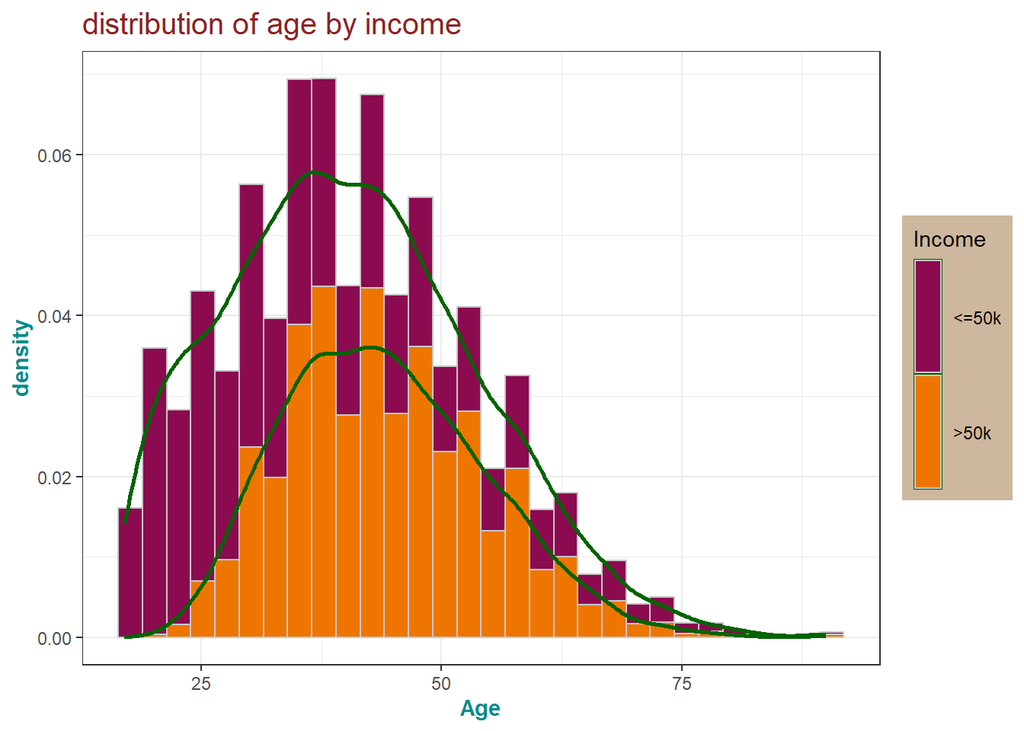

```r
# plots
data1 %>%
  ggplot(aes(x = age, fill = income)) +
  geom_histogram(aes(y = ..density..), color = 'grey78') +
  theme_bw()+
  stat_density(geom = 'line', color = 'darkgreen', size = 1) +
  ggtitle("distribution of age by income") +
  xlab("Age") +
  scale_fill_manual(values=c("deeppink4", "darkorange2"), labels = c("<=50k", ">50k")) +
  theme(plot.title = element_text(color = "brown4", size = 15), # Configure the main plot title
        axis.title = element_text(face = "bold", color = "cyan4"),
        # Change legend background color
        legend.background = element_rect(fill = "bisque3"),
        legend.key = element_rect(fill = "darkgreen", color = NA),
        # Change legend key size and key width
        legend.key.size = unit(2, "cm"),
        legend.key.width = unit(0.5,"cm")
        ) +
  labs(fill = "Income")
```

Distribution of the age variable. Distribution is right-skewed. Maximum value is 90 and the smallest value is 17.The most frequent age is approximately between 30-40 years old.

Distribution of the age variable. Distribution is right-skewed. The most frequent age is approximately between 30-40 years old. Minimum value for age is 17 and maximum value for age is 90. Group having income more than 50K is smaller comparing to group with income less than 50K. Group with 50K or more increases with age while group with less than 50K is dropping.

```r
# Creating age groups
data_age_groups = data1 %>%
  mutate(
    # Create categories
    age_group = case_when(
      age <= 25            ~ "17-25",
      age > 25 & age <= 35 ~ "26-35",
      age > 35 & age <= 50 ~ "36-50",
      age > 50 & age <= 70 ~ "51-70",
      age > 70             ~ "> 70"
    ),

    age_group = factor(
      age_group,
      level = c("17-25", "26-35","36-50", "51-70", "> 70")
    )
  )

data_age_groups1 <- data_age_groups %>%
  group_by(age_group) %>%
  summarise(number = n())
```

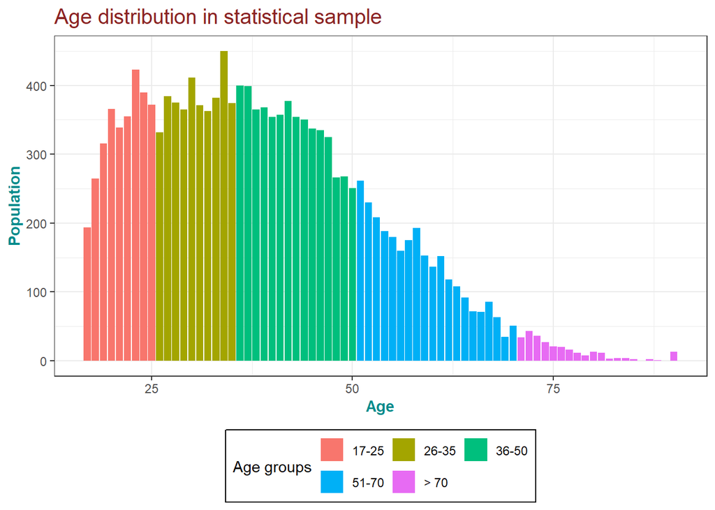

```r
ggplot(data = data_age_groups, aes(x = age, fill = factor(age_group))) +
  geom_bar(position = 'dodge') +
  ggtitle('Age distribution in statistical sample') +
  xlab('Age') +
  ylab('Population') +
  theme_bw() +
  theme(legend.position = 'bottom') +
  guides(fill = guide_legend(nrow = 2,byrow = TRUE)) +
  theme(plot.title = element_text(color = "brown4", size = 15),
        axis.title = element_text(face = "bold", color = "cyan4"),
        legend.background = element_rect(color = "black")) +
  labs(fill = "Age groups")
```

we can see that the biggest group in our dataset is 36-50.

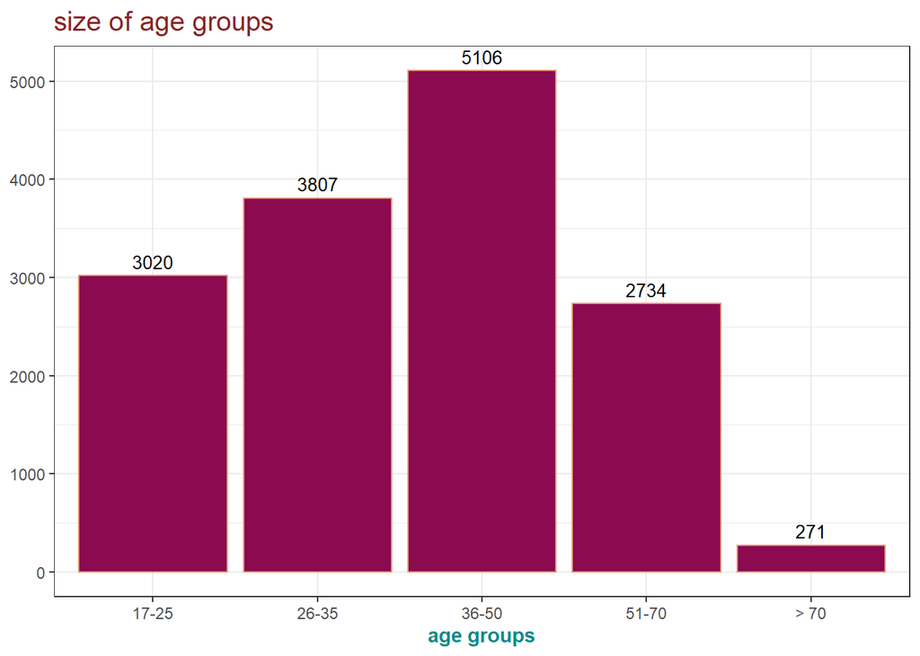

```r
ggplot(data = data_age_groups1, aes(x = age_group, y = number)) +
  geom_bar(stat = 'identity', fill = 'deeppink4', color = 'darksalmon') +
  theme_bw() +
  geom_text(aes(label = number), vjust = -0.5, color = 'black', size = 3.5) +
  ggtitle("size of age groups") +
  theme(plot.title = element_text(color = "brown4", size = 15),
        axis.title = element_text(face = "bold", color = "cyan4"),
        axis.title.y = element_blank()) +
  xlab('age groups')
```

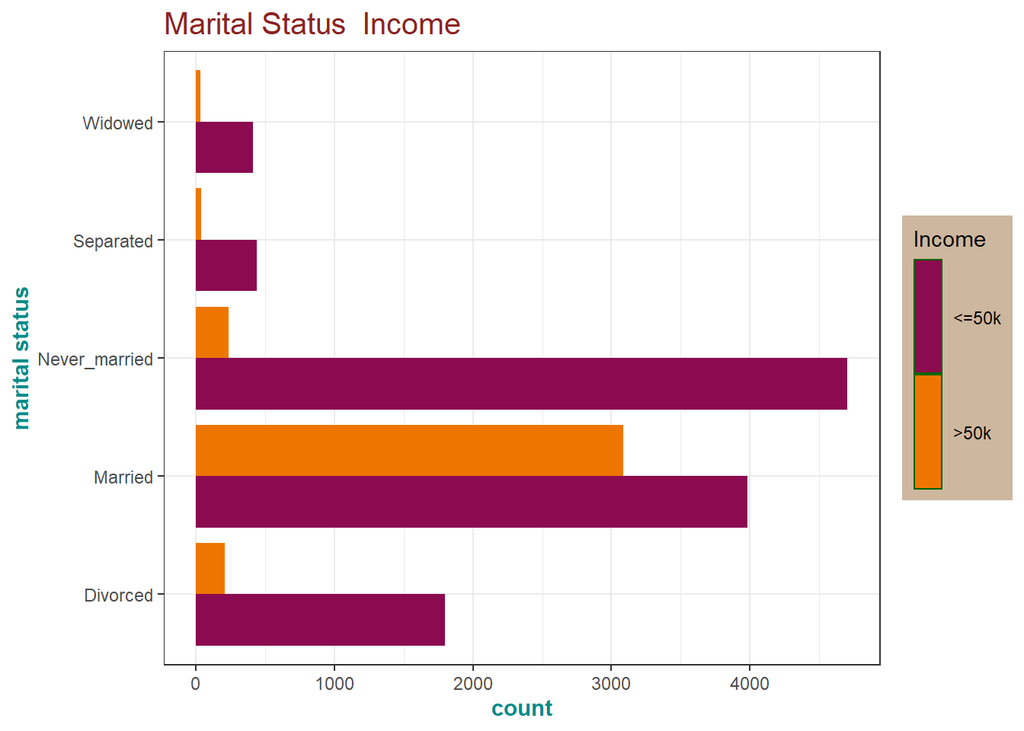

```r
data1 %>%
  ggplot(aes(x = marital_status, fill = income)) +
  geom_bar(position = "dodge", width = 0.87) +
  theme_bw() +
  coord_flip() +
  ggtitle("Marital Status  Income") +
  scale_fill_manual(values=c("deeppink4", "darkorange2"), labels = c("<=50k", ">50k")) +
  theme(plot.title = element_text(color = "brown4", size = 15), # Configure the main plot title
        axis.title = element_text(face = "bold", color = "cyan4"),
        # Change legend background color
        legend.background = element_rect(fill = "bisque3"),
        legend.key = element_rect(fill = "darkgreen", color = NA),
        # Change legend key size and key width
        legend.key.size = unit(2, "cm"),
        legend.key.width = unit(0.5,"cm")
        ) +

  labs(fill = "Income") +
  xlab("marital status")
```

In our data Female group less represented than the another with 4986 .

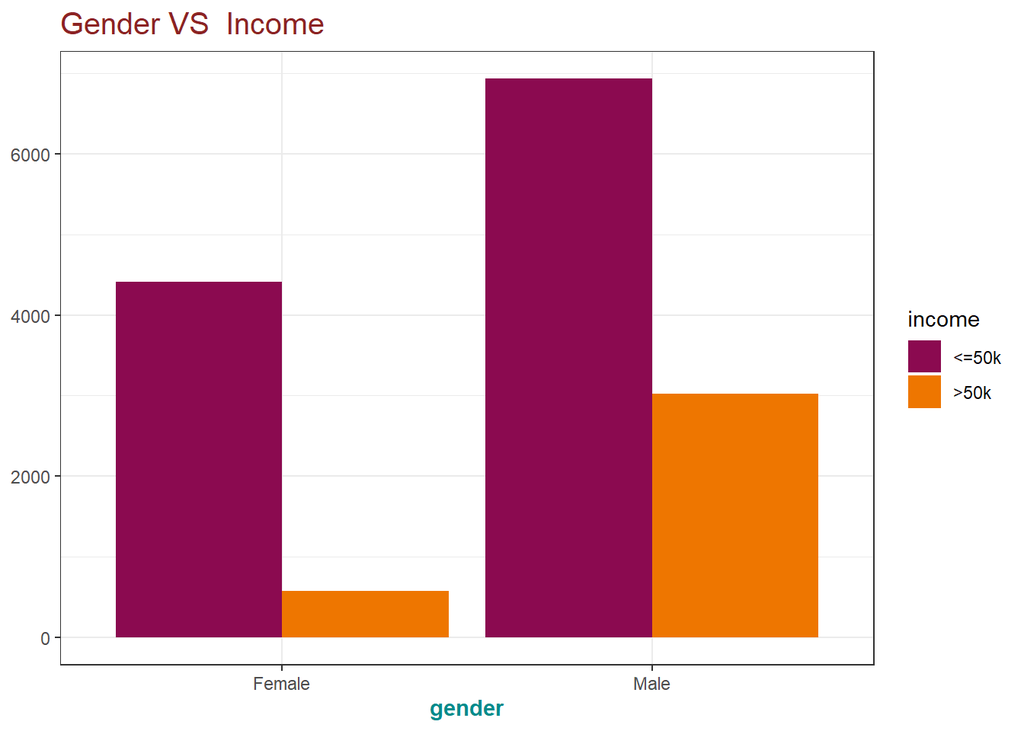

```r
data1 %>%
  ggplot(aes(x = gender, fill = income)) + geom_bar(position="dodge") +
  theme_bw() +
  ggtitle("Gender VS  Income") +
  scale_fill_manual(values=c("deeppink4", "darkorange2"), labels = c("<=50k", ">50k")) +
  theme(plot.title = element_text(color = "brown4", size = 15),
        axis.title = element_text(face = "bold", color = "cyan4"),
        axis.title.y = element_blank()) +
  xlab("gender")
```

In our data Male group is more represented than the other with 9952 observations.

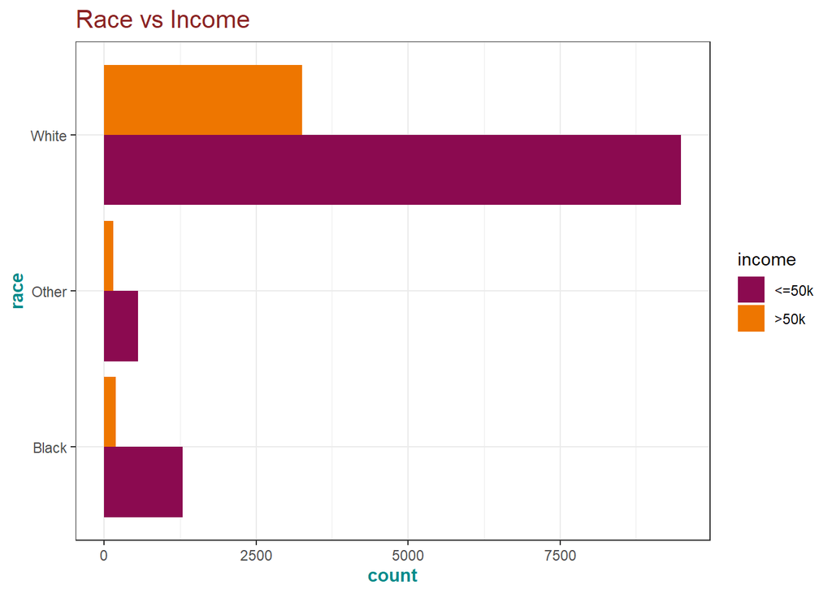

```r
data1 %>%
  ggplot(aes(x = race, fill = income)) + geom_bar(position="dodge") +
  theme_bw()+
  coord_flip() +
  scale_fill_manual(values=c("deeppink4", "darkorange2"), labels = c("<=50k", ">50k")) +
  theme(plot.title = element_text(color = "brown4", size = 15),
           axis.title = element_text(face = "bold", color = "cyan4")) +
  xlab("race") +
  ggtitle("Race vs Income")
```

The most representative race in our data is White with 12746 observations. Other races underrepresented in our data hence they will be combined into one category.

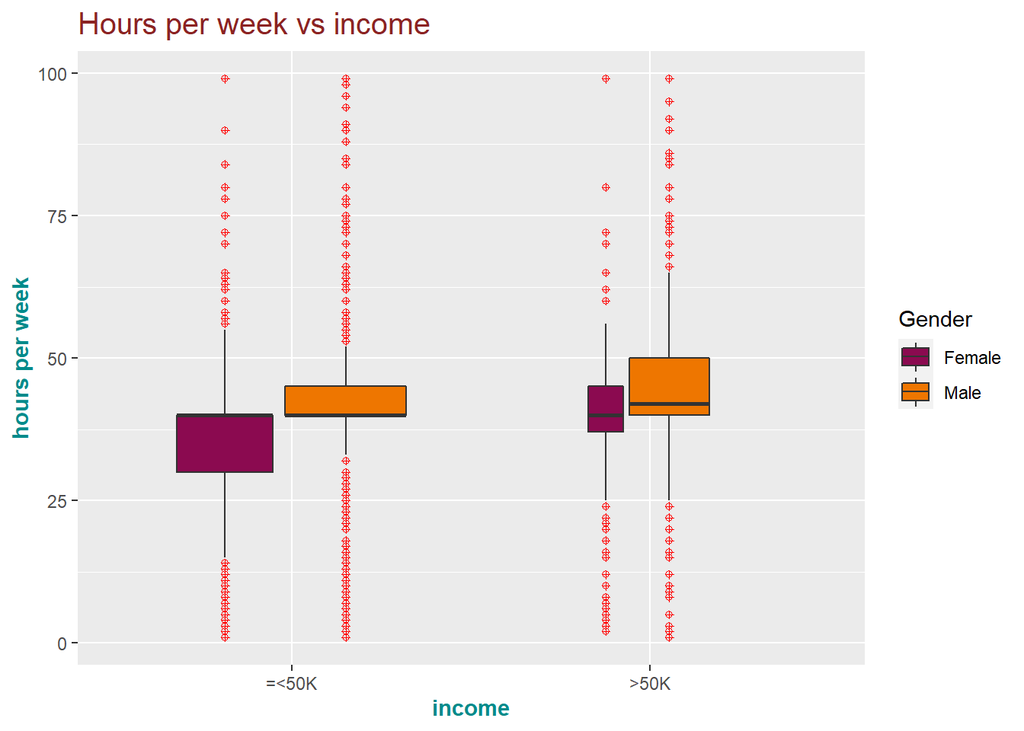

```r
data1 %>%
  ggplot(aes(x = income, y = hours_per_week, fill = factor(gender))) +
  geom_boxplot(varwidth = TRUE, outlier.shape = 10, outlier.color = 'red') +
  scale_fill_manual(values=c("deeppink4", "darkorange2")) +
  theme(plot.title = element_text(color = "brown4", size = 15),
           axis.title = element_text(face = "bold", color = "cyan4")) +
  ylab("hours per week") +
  xlab("income") +
  ggtitle("Hours per week vs income") +
  guides(fill=guide_legend(title="Gender")) +
  scale_x_discrete(labels=c("0" = "=<50K", "1" = ">50K"))
```

On the graphed it is illustrated that group which has income 50K or more works more hours during the week comparing to group which has less than 50K.

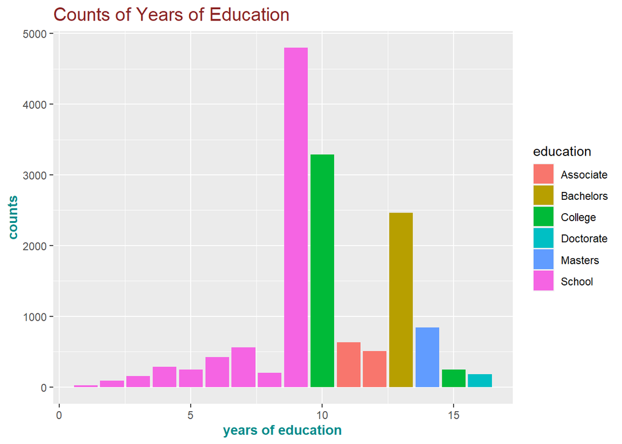

```r
ggplot(data = data1) +
  aes(x=education_num, fill=education) +
  geom_bar() +
  theme(plot.title = element_text(color = "brown4", size = 15),
        axis.title = element_text(face = "bold", color = "cyan4")) +
  xlab("years of education") +
  ylab("counts") +
  ggtitle("Counts of Years of Education")
```

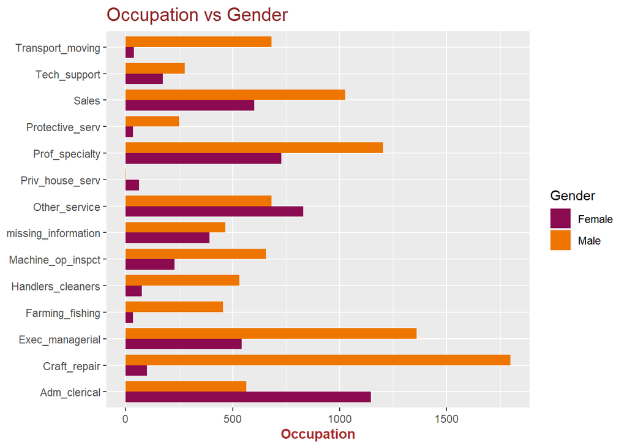

```r
ggplot(data = data1,aes( x = occupation, fill = factor(gender))) +
  geom_bar(width = 0.8, position = 'dodge') +
  labs(x = 'Work hours per week',
       y = 'Occupation',
       title = 'Occupation vs Gender') +
  coord_flip() +
  scale_fill_manual(values=c("deeppink4", "darkorange2")) +
  theme(plot.title = element_text(color = "brown4", size = 15),
        axis.title = element_text(face = "bold", color = "brown"),
        axis.title.y = element_blank()) +
  guides(fill=guide_legend(title="Gender"))
```

We can see that the biggest group is working as Prof_specialty with 1930 observations. The smallest group is Priv_house_serv with 65

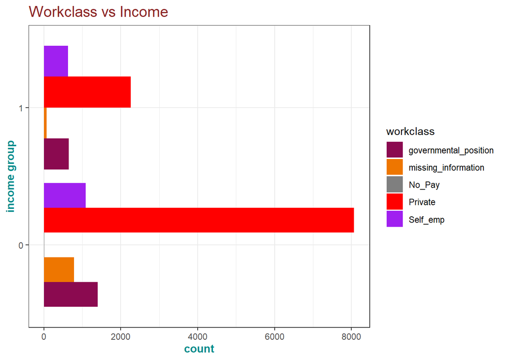

```r
#### DONT KNOW HOW TO COMMENT!!!!!!!!!!
data1 %>%
  ggplot(aes(x = income, fill = workclass)) + geom_bar(position="dodge") +
  theme_bw()+
  coord_flip() +
  scale_fill_manual(values=c("deeppink4", "darkorange2", "grey50", "red", "purple", "seagreen3", "yellow", "blue", "pink")) +
  theme(plot.title = element_text(color = "brown4", size = 15),
           axis.title = element_text(face = "bold", color = "cyan4")) +
  xlab("income group") +
  ggtitle("Workclass vs Income")
```

```r
#data1 %>% group_by(workclass) %>% count(income) %>% arrange(desc(n)) %>% slice(1:2) %>% dplyr::select(workclass)
```

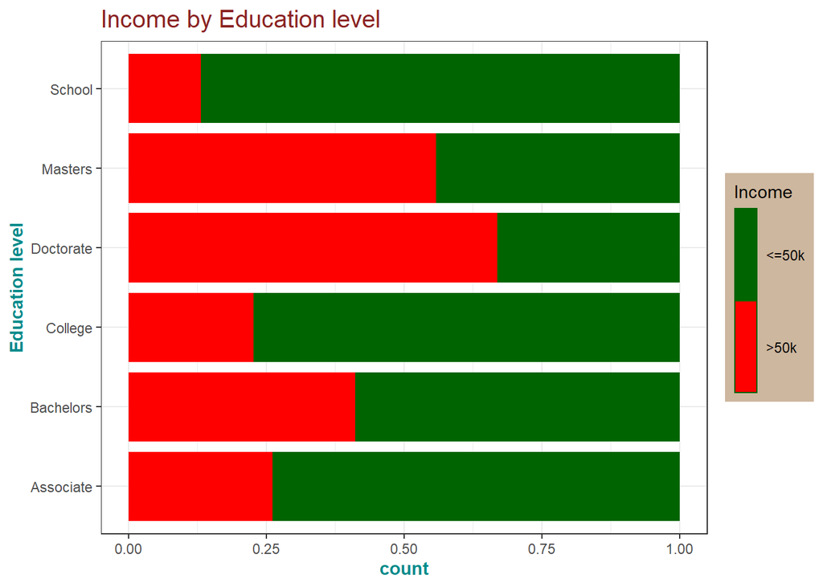

```r
data1 %>%
  ggplot(aes(x = education, fill = income)) +
  geom_bar(position = "fill", width = 0.87) +
  theme_bw() +
  coord_flip() +
  ggtitle("Income by Education level") +
  scale_fill_manual(values=c("darkgreen", "red"), labels = c("<=50k", ">50k")) +
  theme(plot.title = element_text(color = "brown4", size = 15), # Configure the main plot title
        axis.title = element_text(face = "bold", color = "cyan4"),
        # Change legend background color
        legend.background = element_rect(fill = "bisque3"),
        legend.key = element_rect(fill = "darkgreen", color = NA),
        # Change legend key size and key width
        legend.key.size = unit(2, "cm"),
        legend.key.width = unit(0.5,"cm")
        ) +
  labs(fill = "Income") +
  xlab("Education level")
```

```r
#People with `r data1 %>% group_by(education) %>% count(income) %>% filter(income == 1) %>% arrange(desc(n)) %>% slice(1) %>% dplyr::select(education)` degrees has the biggest number of observations in group where people are getting >50K. So, with the higher education people are tend to get more money. At the opposite group where people are getting <=50K they tend to belong to `r data1 %>% group_by(education) %>% count(income) %>% filter(income == 0) %>% arrange(desc(n)) %>% slice(1) %>% dplyr::select(education)` group.
```

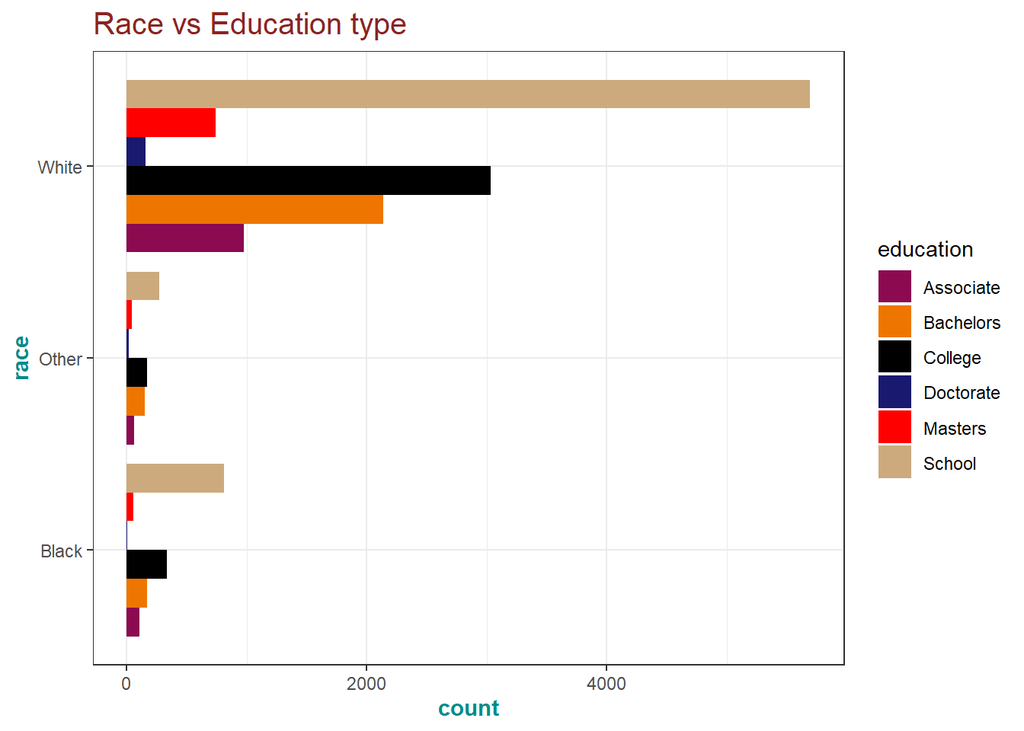

```r
data1 %>%
  ggplot(aes(x =race  , fill = education)) + geom_bar(position="dodge") +
  theme_bw()+
  coord_flip() +
  scale_fill_manual(values=c("deeppink4", "darkorange2", "black", "midnightblue","red", "burlywood3")) +
  theme(plot.title = element_text(color = "brown4", size = 15),
           axis.title = element_text(face = "bold", color = "cyan4")) +
  xlab("race") +
  ggtitle("Race vs Education type")
```

In general, people with `White` race tend to go after their education more than other races. Whereas, being High School grad is the most popular education type within black race.

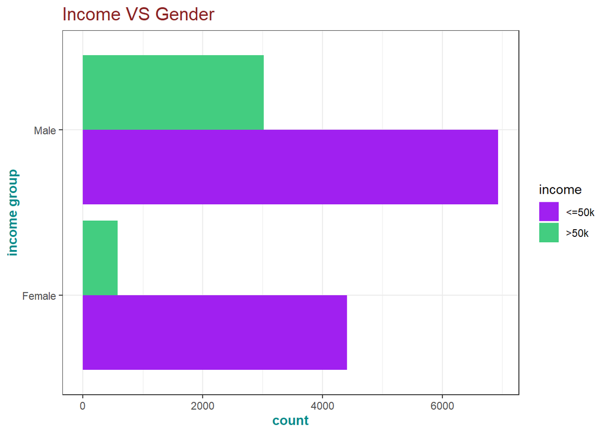

```r
data1 %>%
  ggplot(aes(x = gender, fill = income)) + geom_bar(position="dodge") +
  theme_bw()+
  coord_flip() +
  scale_fill_manual(values=c( "purple", "seagreen3"), labels = c("<=50k", ">50k")) +
  theme(plot.title = element_text(color = "brown4", size = 15),
           axis.title = element_text(face = "bold", color = "cyan4")) +
  xlab("income group") +
  ggtitle("Income VS Gender")
```

```r
data_education_groups <- data1 %>%
  group_by(education) %>%
  summarise(number = n())
```

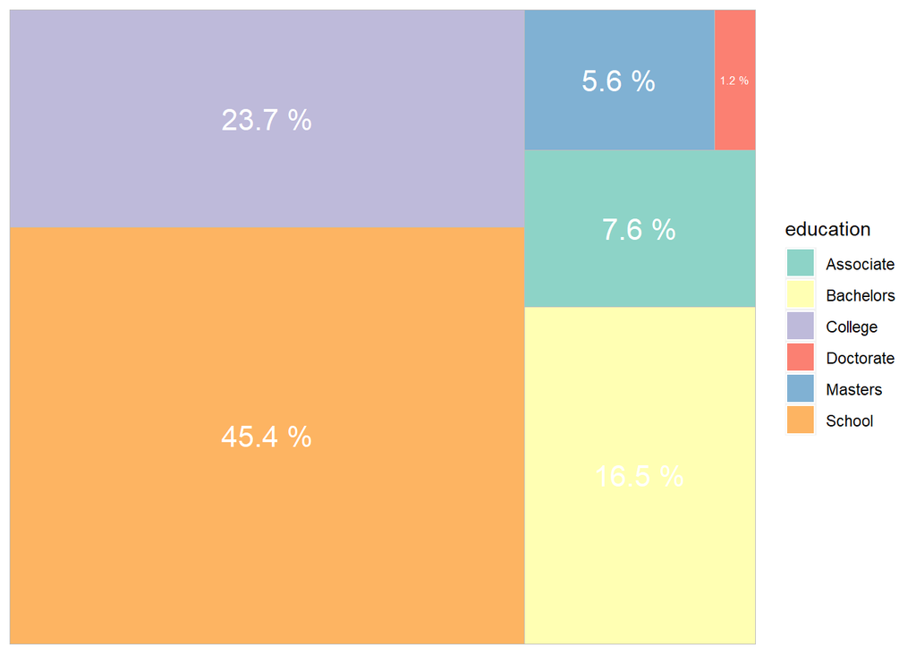

```r
#install.packages("treemapify")
library(treemapify)

library(ggplot2)

ggplot(data_education_groups, aes(area = number, fill = education, label =paste(round(number / sum(number) * 100, 1),"%"))) +
  geom_treemap()+
  geom_treemap_text(colour = "white",
                    place = "centre",
                    size = 16) +
  scale_fill_brewer(palette = "Set3")
```

```r
library(caret)

options(contrasts = c("contr.treatment",
                      "contr.treatment"))

set.seed(123)
splitting <- createDataPartition(data1$income,
                                          p = 0.7,
                                          list = FALSE)

train_data = data1[splitting,]
test_data = data1[-splitting,]
```

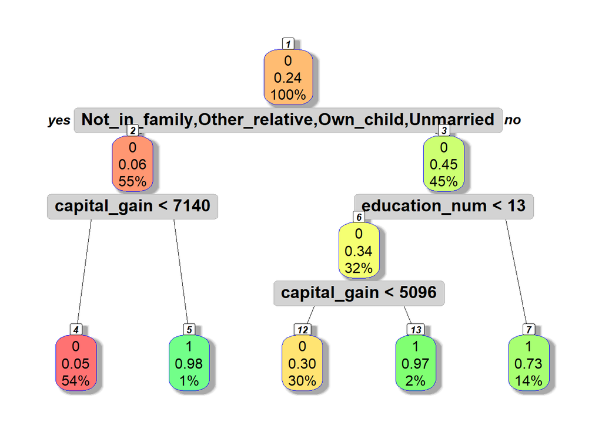